# Titanic Disaster

Vasil Yordanov

26 June 2017

## Logistic Regression without any feature engineering

This is my first Kaggle kernel. Here I am going to predict who is going to survive the Titanic distaster using logistic regression. First let’s load the datasets provided by Kaggle.

```r
train = read.csv("train.csv", stringsAsFactors = F)
test = read.csv("test.csv", stringsAsFactors = F)
```

Next let’s inspect the training dataset, I are currently not focusing on the testing dataset as its structure is equivalent with the training dataset and only the number of observations will be different.

```r
str(train)
```

```
## 'data.frame':    891 obs. of  12 variables:
##  $ PassengerId: int  1 2 3 4 5 6 7 8 9 10 ...
##  $ Survived   : int  0 1 1 1 0 0 0 0 1 1 ...
##  $ Pclass     : int  3 1 3 1 3 3 1 3 3 2 ...
##  $ Name       : chr  "Braund, Mr. Owen Harris" "Cumings, Mrs. John Bradley (Florence Briggs Thayer)" "Heikkinen, Miss. Laina" "Futrelle, Mrs. Jacques Heath (Lily May Peel)" ...
##  $ Sex        : chr  "male" "female" "female" "female" ...
##  $ Age        : num  22 38 26 35 35 NA 54 2 27 14 ...
##  $ SibSp      : int  1 1 0 1 0 0 0 3 0 1 ...
##  $ Parch      : int  0 0 0 0 0 0 0 1 2 0 ...
##  $ Ticket     : chr  "A/5 21171" "PC 17599" "STON/O2. 3101282" "113803" ...
##  $ Fare       : num  7.25 71.28 7.92 53.1 8.05 ...
##  $ Cabin      : chr  "" "C85" "" "C123" ...
##  $ Embarked   : chr  "S" "C" "S" "S" ...
```

Here is the place to include some information about the variables:

- PassengerId - ID of the passenger (this will definately be exluded from our regression model)
- Survived - factor variable indicating if the passenger survived (1) or not (0) the accident
- Pclass - factor variable indicating the ticket class 1st (upper), 2nd (middle) or 3rd (lower)
- Name - name of the passenger
- Sex - gender of the passenger
- Age - fractional if less than 1 and in form xx.5 if estimated
- SibSp - number of siblings / spouses aboard the Titanic
- Parch - number of parents / children aboard the Titanic
- Ticket - ticket number
- Fare - passenger fare
- Cabin - cabin number
- Embarked - facotr variable indicating the port of embarkation C (Cherbourg), Q (Queenstown), S (Southampton)

This reminds me that I need to convert some variables:

```r
train$Survived = as.factor(as.character(train$Survived))
train$Pclass = as.factor(as.character(train$Pclass))
train$Sex = as.factor(as.character(train$Sex))
train$Embarked = as.factor(as.character(train$Embarked))

test$Pclass = as.factor(as.character(test$Pclass))
test$Sex = as.factor(as.character(test$Sex))
test$Embarked = as.factor(as.character(test$Embarked))
```

Let’s continue with our data exploration:

```r
summary(train)
```

```
##   PassengerId    Survived Pclass      Name               Sex
##  Min.   :  1.0   0:549    1:216   Length:891         female:314
##  1st Qu.:223.5   1:342    2:184   Class :character   male  :577
##  Median :446.0            3:491   Mode  :character
##  Mean   :446.0
##  3rd Qu.:668.5
##  Max.   :891.0
##
##       Age            SibSp           Parch           Ticket
##  Min.   : 0.42   Min.   :0.000   Min.   :0.0000   Length:891
##  1st Qu.:20.12   1st Qu.:0.000   1st Qu.:0.0000   Class :character
##  Median :28.00   Median :0.000   Median :0.0000   Mode  :character
##  Mean   :29.70   Mean   :0.523   Mean   :0.3816
##  3rd Qu.:38.00   3rd Qu.:1.000   3rd Qu.:0.0000
##  Max.   :80.00   Max.   :8.000   Max.   :6.0000
##  NA's   :177
##       Fare           Cabin           Embarked
##  Min.   :  0.00   Length:891          :  2
##  1st Qu.:  7.91   Class :character   C:168
##  Median : 14.45   Mode  :character   Q: 77
##  Mean   : 32.20                      S:644
##  3rd Qu.: 31.00
##  Max.   :512.33
##
```

From the summary I can see that there are 177 missing observations for the Age variable. I need to investigate this further in order to decide what to do with these 177 observations. Thus I will make a subset of the training dataset containing only the observations with missing age.

```r
missing = subset(train, is.na(Age))
summary(missing)
```

```
##   PassengerId    Survived Pclass      Name               Sex
##  Min.   :  6.0   0:125    1: 30   Length:177         female: 53
##  1st Qu.:230.0   1: 52    2: 11   Class :character   male  :124
##  Median :452.0            3:136   Mode  :character
##  Mean   :435.6
##  3rd Qu.:634.0
##  Max.   :889.0
##
##       Age          SibSp           Parch           Ticket
##  Min.   : NA   Min.   :0.000   Min.   :0.0000   Length:177
##  1st Qu.: NA   1st Qu.:0.000   1st Qu.:0.0000   Class :character
##  Median : NA   Median :0.000   Median :0.0000   Mode  :character
##  Mean   :NaN   Mean   :0.565   Mean   :0.1808
##  3rd Qu.: NA   3rd Qu.:0.000   3rd Qu.:0.0000
##  Max.   : NA   Max.   :8.000   Max.   :2.0000
##  NA's   :177
##       Fare           Cabin           Embarked
##  Min.   :  0.00   Length:177          : 0
##  1st Qu.:  7.75   Class :character   C:38
##  Median :  8.05   Mode  :character   Q:49
##  Mean   : 22.16                      S:90
##  3rd Qu.: 24.15
##  Max.   :227.53
##
```

Looking on the summary doesn’t bring much insight if these passenger do have something in common, other that the missing Age. Thus I will inspect this visually.

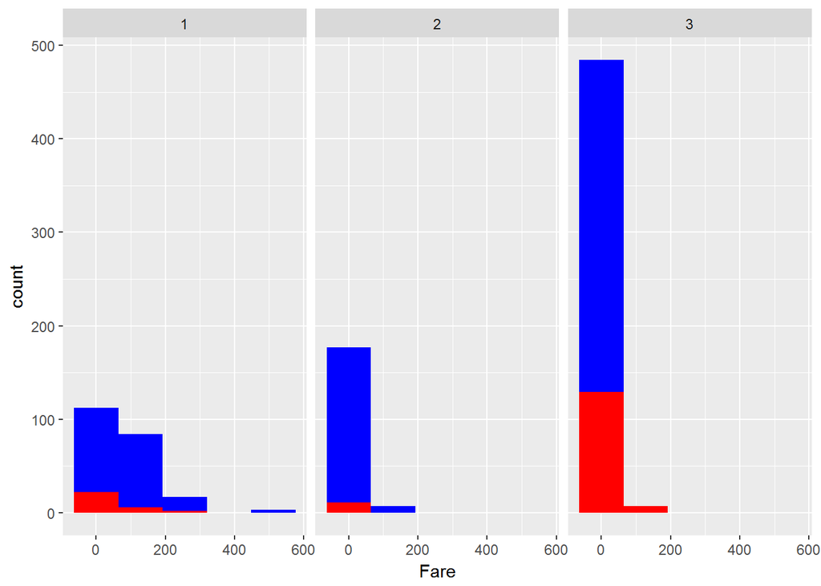

```r
library(ggplot2)

ggplot() +
    geom_histogram(data = train, mapping = aes(x = Fare), fill = "blue", bins = 5) +
    geom_histogram(data = missing, mapping = aes(x = Fare), fill = "red", bins = 5) +
    facet_grid(.~ Pclass)
```

From this graph we can notice that most of the passengers with missing Age also have common Pclass value of 3. Here is a summary table of that:

```r
table(missing$Pclass, missing$Sex)
```

```
##
##     female male
##   1      9   21
##   2      2    9
##   3     42   94
```

If we simply omit these observations in our logistics regression model we will introduce selection bias in our model as we will remove mostly male, low-fare, low-class passengers. Thus we want to impute the missing data

```r
library(mice)
imputed = complete(mice(train,m=5,maxit=50,meth='pmm',seed=500))
imputed.test = complete(mice(test,m=5,maxit=50,meth='pmm',seed=500))
```

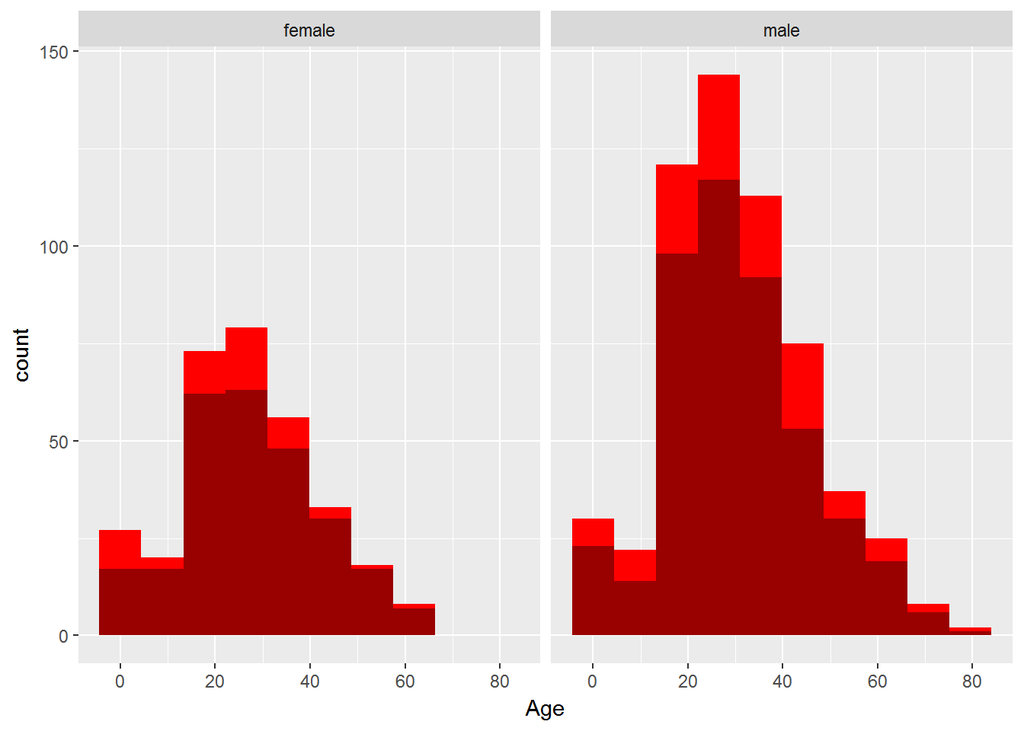

```r
ggplot() +
    geom_histogram(data = imputed, mapping = aes(x = Age), fill = "red", bins = 10) +
    geom_histogram(data = train, mapping = aes(x = Age), fill = "black", bins = 10, alpha = 0.4) +
    facet_grid(. ~ Sex)
```

After the imputation I do not have anymore missing data and the Age distribution among women and men seems to be unchanged. Before continuing with my exploratory data analysis I want to construct a dummy baseline model for prediction:

```r
table(train$Survived)
```

```
##
##   0   1
## 549 342
```

My baseline model will predict that Survived = 0, no matter what and it will be accurate in approximately 62% (549/891) of the cases (which is pretty big accuracy by the way). Thus I need to build a logistic regression model later which can beat that. But before that I need to identify the significant variables which can help to improve my prediction score.

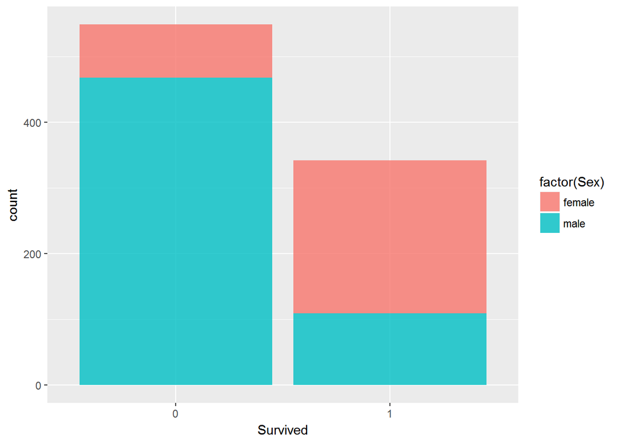

```r
ggplot() +
    geom_histogram(data = imputed, mapping = aes(x = Survived, fill = factor(Sex)), alpha = 0.8, stat="count")
```

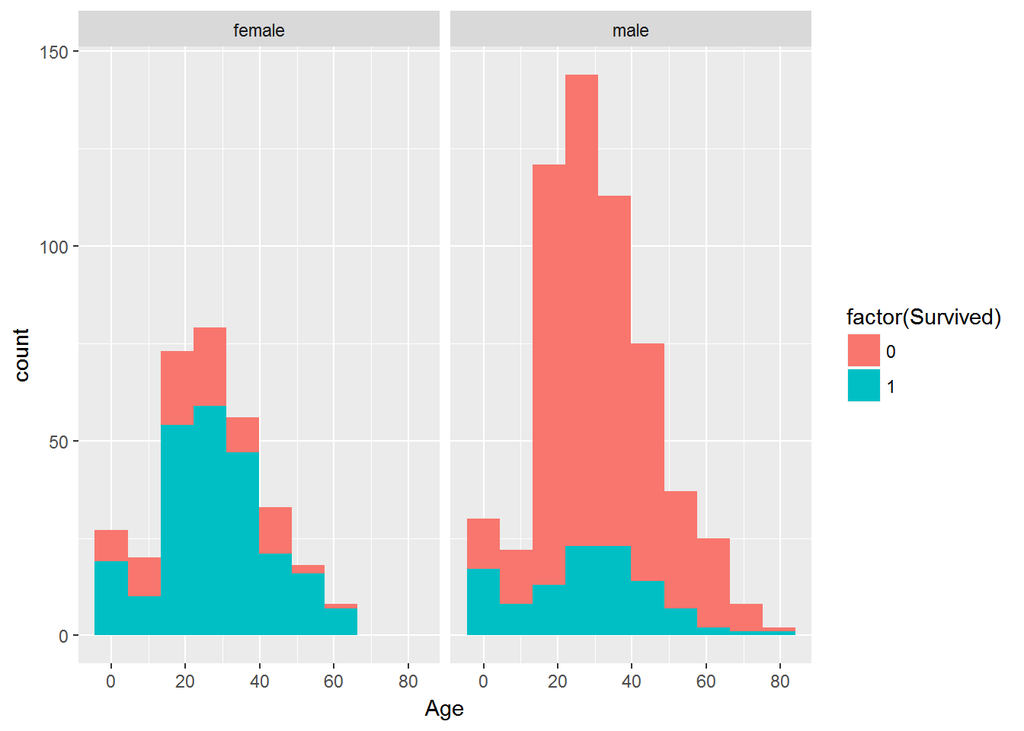

```r
ggplot() +
    geom_histogram(data = imputed, mapping = aes(x = Age, fill = factor(Survived)), bins = 10) +
    facet_grid(. ~ Sex)
```

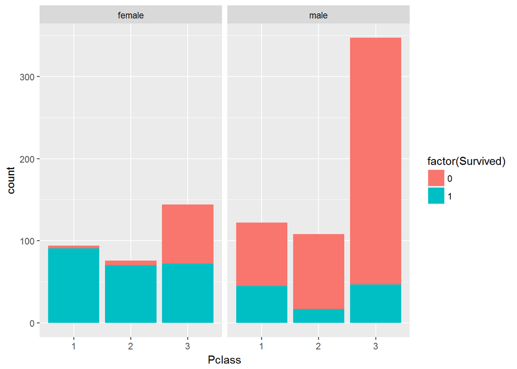

```r
ggplot() +
    geom_histogram(data = imputed, mapping = aes(x = Pclass, fill = factor(Survived)), stat="count") +
    facet_grid(. ~ Sex)
```

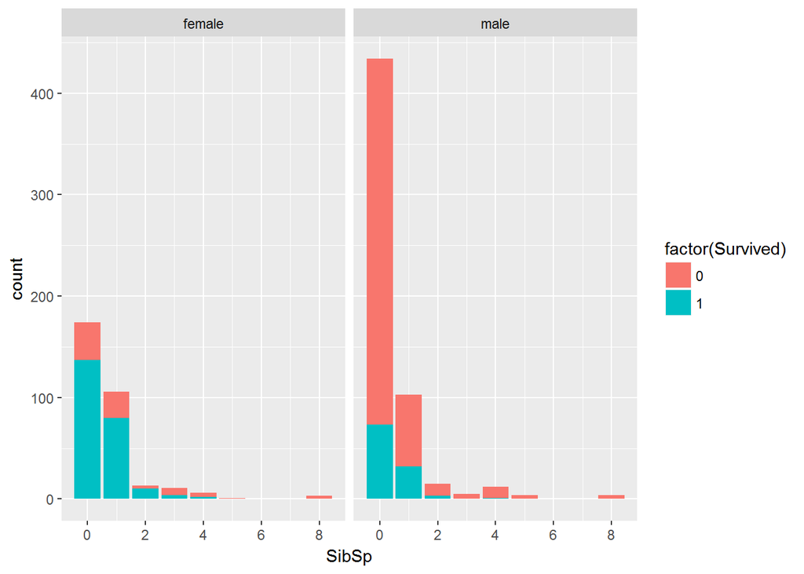

```r
ggplot() +
    geom_histogram(data = imputed, mapping = aes(x = SibSp, fill = factor(Survived)), stat="count") +
    facet_grid(. ~ Sex)
```

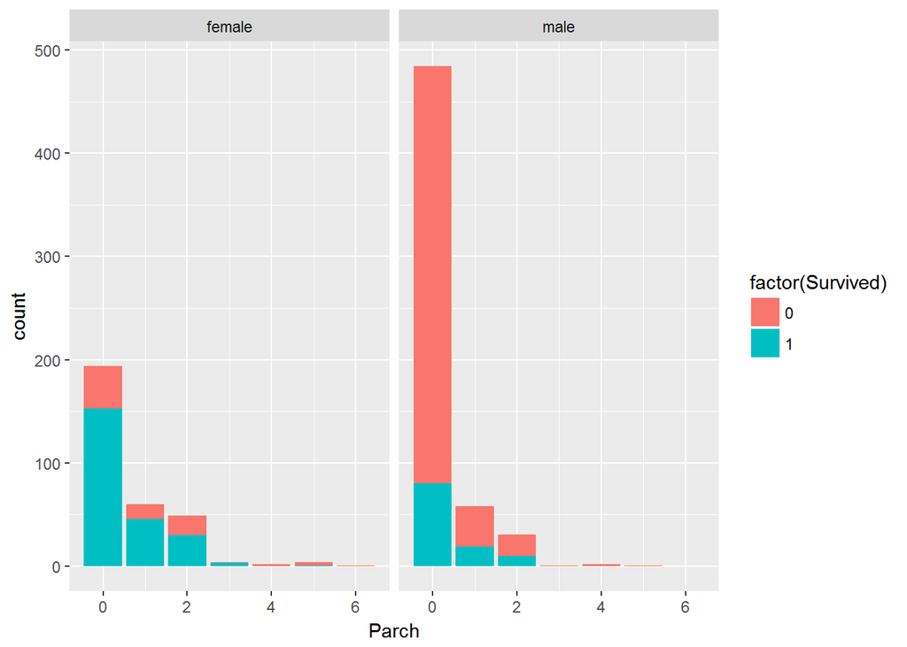

```r
ggplot() +
    geom_histogram(data = imputed, mapping = aes(x = Parch, fill = factor(Survived)), stat="count") +
    facet_grid(. ~ Sex)
```

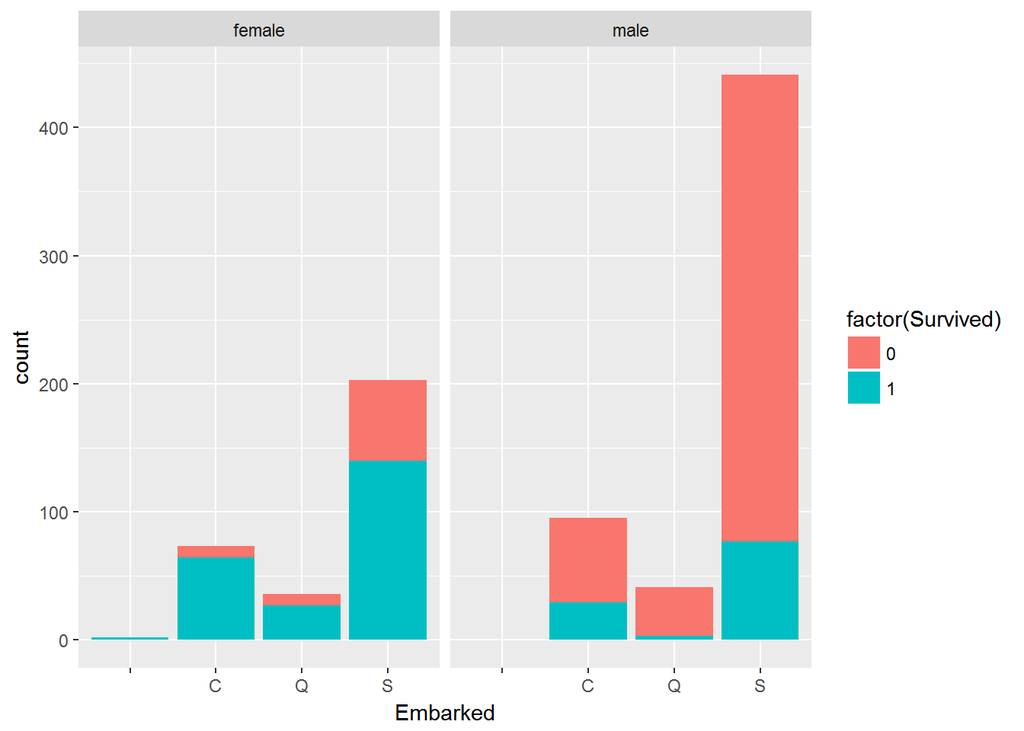

```r
ggplot() +
    geom_histogram(data = imputed, mapping = aes(x = Embarked, fill = factor(Survived)), stat="count") +
    facet_grid(. ~ Sex)
```

Building my first logistic regression model

```r
imputed = subset(imputed, select = -c(PassengerId))
model1 = glm(Survived ~ Sex + Pclass + Embarked + SibSp, data = imputed, family=binomial)
predict1 = predict(model1, type="response")

a = table(imputed$Survived, predict1 >= 0.5)

TP = a[2,2] # true positives
TN = a[1,1] # true negatives
FP = a[1,2] # false positives
FN = a[2,1] # false negatives

sensitivity = TP/(TP+FN)
specificity = TN/(TN+FN)
accuracy = (TN + TP)/(TN + TP + FP + FN)
```

The accuracy of this model is 79.2% on the training set. Let’s see what’s the AUC value:

```r
library(ROCR)
ROCRpred = prediction(predict1, train$Survived)
as.numeric(performance(ROCRpred, "auc")@y.values)
```

```
## [1] 0.841578
```

Well this AUC value is quite high, which means that my model quite differentiate between the passengers who survived and those who didn’t.

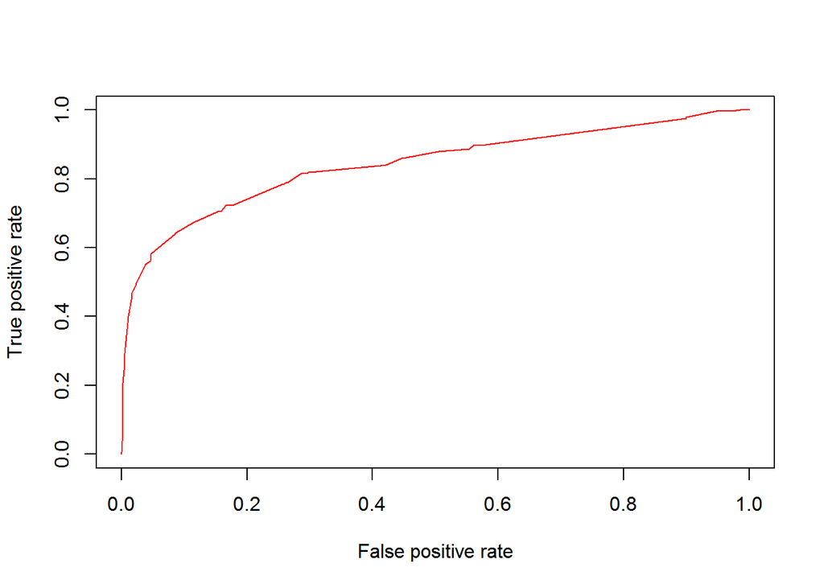

```r
perf = performance(ROCRpred,measure = "tpr", x.measure = "fpr")
plot(perf, col=rainbow(10))
```

## Logistic Regression using feature engineering

Well my logistic regression model works a bit better than the baseline model but I believe it can do much better if I apply feature engineering. But first I will copy the missing age observations to my training set:

```r
train$Age = imputed$Age
test$Age = imputed.test$Age
```

First I will start by adding a factor variable indicating of the passenger is a child:

```r
train$child = train$Age < 18
test$child = test$Age < 18
```

Next I will add a numerical variable showing the number of accompanying family members:

```r
train$familySize = train$SibSp + train$Parch + 1
test$familySize = test$SibSp + test$Parch + 1
```

Now I will separate the title from the passengers’ names and put it in an additional variable:

```r
train$Title = gsub('(.*, )|(\\..*)', '', train$Name)
test$Title = gsub('(.*, )|(\\..*)', '', test$Name)
```

```r
# code taken 1:1 from Megan Risdal

rare_title <- c('Dona', 'Lady', 'the Countess','Capt', 'Col', 'Don',
                'Dr', 'Major', 'Rev', 'Sir', 'Jonkheer')

train$Title[train$Title == 'Mlle']        <- 'Miss'
train$Title[train$Title == 'Ms']          <- 'Miss'
train$Title[train$Title == 'Mme']         <- 'Mrs'
train$Title[train$Title %in% rare_title]  <- 'Rare Title'

test$Title[test$Title == 'Mlle']        <- 'Miss'
test$Title[test$Title == 'Ms']          <- 'Miss'
test$Title[test$Title == 'Mme']         <- 'Mrs'
test$Title[test$Title %in% rare_title]  <- 'Rare Title'
```

```r
train$mother =  train$Sex == "female" & train$Parch > 0 & train$child == FALSE & train$Title != "Miss"
test$mother = test$Sex == 'female' & test$Parch > 0 & test$child == FALSE & test$Title != "Miss"
```

Now I will build my second logistic regression model:

```r
data2 = subset(train, select = -c(PassengerId))
model2 = glm(Survived ~ Sex + Pclass + Embarked + SibSp + mother + child + Title + familySize, data = data2, family=binomial)
predict2 = predict(model2, type="response")

a = table(data2$Survived, predict2 >= 0.5)

TP = a[2,2] # true positives
TN = a[1,1] # true negatives
FP = a[1,2] # false positives
FN = a[2,1] # false negatives

sensitivity = TP/(TP+FN)
specificity = TN/(TN+FN)
accuracy = (TN + TP)/(TN + TP + FP + FN)
```

The accuracy on the training set increased to 83.16%. Now regarding the new AUC score:

```r
library(ROCR)

ROCRpred = prediction(predict2, data2$Survived)
as.numeric(performance(ROCRpred, "auc")@y.values)
```

```
## [1] 0.8746658
```

Well this AUC value is quite high, which means that my model quite differentiate between the passengers who survived and those who didn’t.

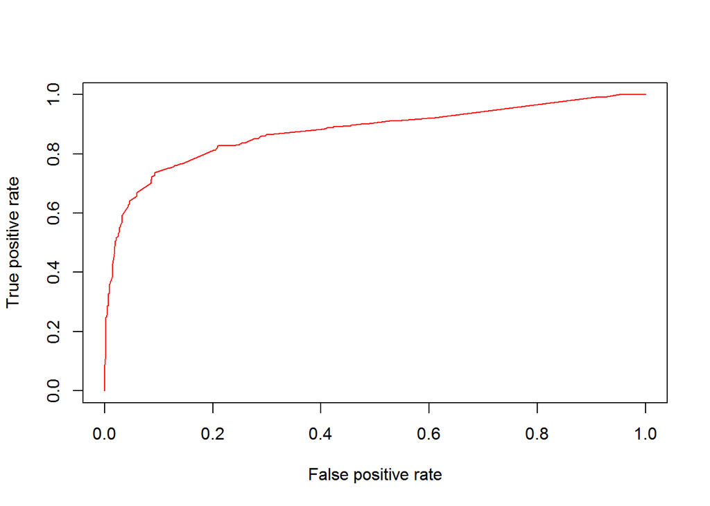

```r
perf2 = performance(ROCRpred,measure = "tpr", x.measure = "fpr")
plot(perf2, col=rainbow(10))
```

Let’s submit this version and see how it will get scored in Kaggle.

```r
prediction2 <- predict(model2, newdata=test, type = "response")
solution2 <- data.frame(PassengerID = test$PassengerId, Survived = round(prediction2, 0))
write.csv(solution2, file = 'model2_Solution.csv', row.names = F)
```

This model was scored 77.99% at Kaggle.

```r
library(randomForest)
```

```r
library(rpart.plot)
library(rpart)
library(caret)
library(e1071)
```

```r
# Defining cross-validation experiment
numFolds = trainControl(method = "cv", number = 50 )
cpGrid = expand.grid( .cp = seq(0.005,0.05,0.0001))

# Performing the cross validation
train(Survived ~ Sex +
                 Pclass +
                 Embarked +
                 SibSp +
                 mother +
                 child +
                 Title +
                 familySize, data = train, method = "rpart", trControl = numFolds, tuneGrid = cpGrid )
```

```
## CART
##
## 891 samples
##   8 predictor
##   2 classes: '0', '1'
##
## No pre-processing
## Resampling: Cross-Validated (50 fold)
## Summary of sample sizes: 873, 873, 873, 873, 874, 873, ...
## Resampling results across tuning parameters:
##
##   cp      Accuracy   Kappa
##   0.0050  0.8026797  0.5639275
##   0.0051  0.8026797  0.5639275
##   0.0052  0.8026797  0.5639275
##   0.0053  0.8026797  0.5639275
##   0.0054  0.8026797  0.5639275
##   0.0055  0.8026797  0.5639275
##   0.0056  0.8026797  0.5639275
##   0.0057  0.8026797  0.5639275
##   0.0058  0.8026797  0.5639275
##   0.0059  0.8026797  0.5639275
##   0.0060  0.8015686  0.5625960
##   0.0061  0.8015686  0.5625960
##   0.0062  0.8015686  0.5625960
##   0.0063  0.8015686  0.5625960
##   0.0064  0.8015686  0.5625960
##   0.0065  0.8015686  0.5625960
##   0.0066  0.8015686  0.5625960
##   0.0067  0.8015686  0.5625960
##   0.0068  0.8015686  0.5625960
##   0.0069  0.8015686  0.5625960
##   0.0070  0.8015686  0.5633645
##   0.0071  0.8015686  0.5633645
##   0.0072  0.8015686  0.5633645
##   0.0073  0.8015686  0.5633645
##   0.0074  0.8015686  0.5633645
##   0.0075  0.8128105  0.5924226
##   0.0076  0.8128105  0.5924226
##   0.0077  0.8128105  0.5924226
```

[output cut: 411 more lines]

```
##   0.0489  0.8094771  0.5928616
##   0.0490  0.8094771  0.5928616
##   0.0491  0.8094771  0.5928616
##   0.0492  0.8094771  0.5928616
##   0.0493  0.8050327  0.5844598
##   0.0494  0.8050327  0.5844598
##   0.0495  0.8050327  0.5844598
##   0.0496  0.8050327  0.5844598
##   0.0497  0.8050327  0.5844598
##   0.0498  0.8050327  0.5844598
##   0.0499  0.8050327  0.5844598
##   0.0500  0.8050327  0.5844598
##
## Accuracy was used to select the optimal model using  the largest value.
## The final value used for the model was cp = 0.0148.
```

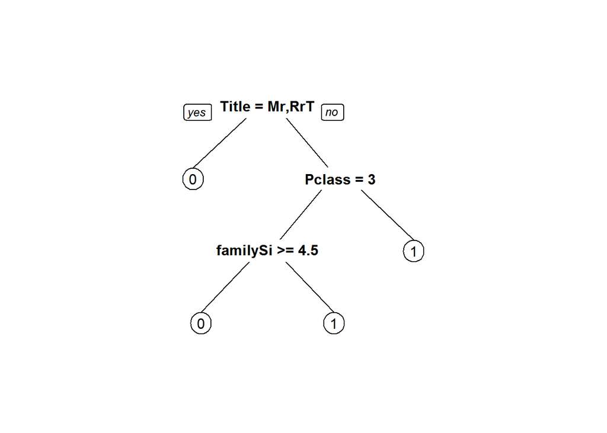

```r
bestTree = rpart(Survived ~ Sex +
                 Pclass +
                 Embarked +
                 SibSp +
                 mother +
                 child +
                 Title +
                 familySize, data = train, method="class", cp = 0.0149)

prp(bestTree)
```

Surpisingly our classification tree looks quite simple.

Let’s submit this version and see how it will get scored in Kaggle.

```r
prediction3 <- predict(bestTree, newdata=test, type = "class")
solution3 <- data.frame(PassengerID = test$PassengerId, Survived = as.numeric(prediction3)-1)
write.csv(solution3, file = 'model3_Solution.csv', row.names = F)
```

This prediction scored 78.947% at Kaggle, which is a bit of disappointment. It seems that I am doing a principal error - in other words I need to take a second look at the data - manually and decide how to proceed.

## Second round of Exploratory Analysis

```r
summary(train)
```

```
##   PassengerId    Survived Pclass      Name               Sex
##  Min.   :  1.0   0:549    1:216   Length:891         female:314
##  1st Qu.:223.5   1:342    2:184   Class :character   male  :577
##  Median :446.0            3:491   Mode  :character
##  Mean   :446.0
##  3rd Qu.:668.5
##  Max.   :891.0
##       Age            SibSp           Parch           Ticket
##  Min.   : 0.42   Min.   :0.000   Min.   :0.0000   Length:891
##  1st Qu.:20.00   1st Qu.:0.000   1st Qu.:0.0000   Class :character
##  Median :28.00   Median :0.000   Median :0.0000   Mode  :character
##  Mean   :29.53   Mean   :0.523   Mean   :0.3816
##  3rd Qu.:38.00   3rd Qu.:1.000   3rd Qu.:0.0000
##  Max.   :80.00   Max.   :8.000   Max.   :6.0000
##       Fare           Cabin           Embarked   child
##  Min.   :  0.00   Length:891          :  2    Mode :logical
##  1st Qu.:  7.91   Class :character   C:168    FALSE:746
##  Median : 14.45   Mode  :character   Q: 77    TRUE :145
##  Mean   : 32.20                      S:644
##  3rd Qu.: 31.00
##  Max.   :512.33
##    familySize        Title             mother
##  Min.   : 1.000   Length:891         Mode :logical
##  1st Qu.: 1.000   Class :character   FALSE:835
##  Median : 1.000   Mode  :character   TRUE :56
##  Mean   : 1.905
##  3rd Qu.: 2.000
##  Max.   :11.000
```

```r
table(train$mother, train$Survived)/nrow(train)
```

```
##
##                  0          1
##   FALSE 0.59820426 0.33894501
##   TRUE  0.01795735 0.04489338
```

```r
table(train$Pclass, train$Survived)/nrow(train)
```

```
##
##              0          1
##   1 0.08978676 0.15263749
##   2 0.10886644 0.09764310
##   3 0.41750842 0.13355780
```

```r
table(train$familySize, train$Survived)/nrow(train)
```

```
##
##                0           1
##   1  0.419753086 0.182940516
##   2  0.080808081 0.099887767
##   3  0.048260382 0.066217733
##   4  0.008978676 0.023569024
##   5  0.013468013 0.003367003
##   6  0.021324355 0.003367003
##   7  0.008978676 0.004489338
##   8  0.006734007 0.000000000
##   11 0.007856341 0.000000000
```

```r
table(train$Title, train$Survived)/nrow(train)
```

```
##
##                        0           1
##   Master     0.019079686 0.025813692
##   Miss       0.061728395 0.145903479
##   Mr         0.489337823 0.090909091
##   Mrs        0.029180696 0.112233446
##   Rare Title 0.016835017 0.008978676
```

```r
table(train$Embarked, train$Survived)/nrow(train)
```

```
##
##               0           1
##     0.000000000 0.002244669
##   C 0.084175084 0.104377104
##   Q 0.052749719 0.033670034
##   S 0.479236813 0.243546577
```

```r
table(train$child, train$Survived)/nrow(train)
```

```
##
##                  0          1
##   FALSE 0.53759820 0.29966330
##   TRUE  0.07856341 0.08417508
```